# Bellabeat

Valesca Bravo

2022-12-21

```r
#install.packages("anytime")
#install.packages("sqldf")
#install.packages("data.table")
#install.packages("magrittr")

library(ggvenn)
library(magrittr)
library(tidyverse)
library(sqldf)
```

```r
library(ggplot2)# plot
library(dplyr)
library(lubridate)
library(anytime)
library(corrplot)
library(ggplot2)
library(data.table)
library(grid)
library(futile.logger)
```

## Introduction

The present study will investigate Bellabeat, a high-tech manufacturer of health-focused products for women. I will work with the 6 steps of the data analysis process: ask, prepare, process, analyze, share, and act, in order to get inside the dataset that have been proposed by Google in its Data Analyst certification.

I am trying to resolve, with the daily data, how people are already using their smart devices,in order to gain insights.

```r
#general
weight <- read_csv("~/Google/Capstone/datasets/weightLogInfo_merged.csv")
sleepDay <- read_csv("~/Google/Capstone/datasets/sleepDay_merged.csv")
heartrate_seconds <- read_csv("~/Google/Capstone/datasets/heartrate_seconds_merged.csv")
#minutes
#hourlyCalories <- read_csv("~/Google/Capstone/datasets/hourlyCalories_merged.csv")
#minuteIntensities <- read_csv("~/Google/Capstone/datasets/minuteIntensitiesNarrow_merged.csv")
#minuteMETs <- read_csv("~/Google/Capstone/datasets/minuteMETsNarrow_merged.csv")
#minuteSteps <- read_csv("~/Google/Capstone/datasets/minuteStepsNarrow_merged.csv")

#Hourly
#hourlyCalories <- read_csv("~/Google/Capstone/datasets/hourlyCalories_merged.csv")
#hourlyIntensities <- read_csv("~/Google/Capstone/datasets/hourlyIntensities_merged.csv")
#hourlySteps <- read_csv("~/Google/Capstone/datasets/hourlySteps_merged.csv")

#daily
dailySteps<- read_csv("~/Google/Capstone/datasets/dailySteps_merged.csv")
dailyIntensities <- read_csv("~/Google/Capstone/datasets/dailyIntensities_merged.csv")
dailyCalories <- read_csv("~/Google/Capstone/datasets/dailyCalories_merged.csv")
dailyActivity <- read_csv("~/Google/Capstone/datasets/dailyActivity_merged.csv")
print("---------------------------------------------weight---------------------------------")
```

```
## [1] "---------------------------------------------weight---------------------------------"
```

```r
glimpse(weight)
```

```
## Rows: 67
## Columns: 8
## $ Id             <dbl> 1503960366, 1503960366, 1927972279, 2873212765, 2873212…
## $ Date           <chr> "5/2/2016 11:59:59 PM", "5/3/2016 11:59:59 PM", "4/13/2…
## $ WeightKg       <dbl> 52.6, 52.6, 133.5, 56.7, 57.3, 72.4, 72.3, 69.7, 70.3, …
## $ WeightPounds   <dbl> 115.9631, 115.9631, 294.3171, 125.0021, 126.3249, 159.6…
## $ Fat            <dbl> 22, NA, NA, NA, NA, 25, NA, NA, NA, NA, NA, NA, NA, NA,…
## $ BMI            <dbl> 22.65, 22.65, 47.54, 21.45, 21.69, 27.45, 27.38, 27.25,…
## $ IsManualReport <lgl> TRUE, TRUE, FALSE, TRUE, TRUE, TRUE, TRUE, TRUE, TRUE, …
## $ LogId          <dbl> 1.462234e+12, 1.462320e+12, 1.460510e+12, 1.461283e+12,…
```

```r
print("---------------------------------------------sleepDay------------------------------")
```

```
## [1] "---------------------------------------------sleepDay------------------------------"
```

```r
glimpse(sleepDay)
```

```
## Rows: 413
## Columns: 5
## $ Id                 <dbl> 1503960366, 1503960366, 1503960366, 1503960366, 150…
## $ SleepDay           <chr> "4/12/2016 12:00:00 AM", "4/13/2016 12:00:00 AM", "…
## $ TotalSleepRecords  <dbl> 1, 2, 1, 2, 1, 1, 1, 1, 1, 1, 1, 1, 1, 1, 1, 1, 1, …
## $ TotalMinutesAsleep <dbl> 327, 384, 412, 340, 700, 304, 360, 325, 361, 430, 2…
## $ TotalTimeInBed     <dbl> 346, 407, 442, 367, 712, 320, 377, 364, 384, 449, 3…
```

```r
print("---------------------------------------------heartrate_seconds----------------------")
```

```
## [1] "---------------------------------------------heartrate_seconds----------------------"
```

```r
glimpse(heartrate_seconds)
```

```
## Rows: 2,483,658
## Columns: 3
## $ Id    <dbl> 2022484408, 2022484408, 2022484408, 2022484408, 2022484408, 2022…
## $ Time  <chr> "4/12/2016 7:21:00 AM", "4/12/2016 7:21:05 AM", "4/12/2016 7:21:…
## $ Value <dbl> 97, 102, 105, 103, 101, 95, 91, 93, 94, 93, 92, 89, 83, 61, 60, …
```

```r
print("---------------------------------------------dailySteps----------------------------")
```

```
## [1] "---------------------------------------------dailySteps----------------------------"
```

```r
glimpse(dailySteps)
```

```
## Rows: 940
## Columns: 3
## $ Id          <dbl> 1503960366, 1503960366, 1503960366, 1503960366, 1503960366…
## $ ActivityDay <chr> "4/12/2016", "4/13/2016", "4/14/2016", "4/15/2016", "4/16/…
## $ StepTotal   <dbl> 13162, 10735, 10460, 9762, 12669, 9705, 13019, 15506, 1054…
```

```r
print("---------------------------------------------dailyCalories-------------------------")
```

```
## [1] "---------------------------------------------dailyCalories-------------------------"
```

```r
glimpse(dailyCalories)
```

```
## Rows: 940
## Columns: 3
## $ Id          <dbl> 1503960366, 1503960366, 1503960366, 1503960366, 1503960366…
## $ ActivityDay <chr> "4/12/2016", "4/13/2016", "4/14/2016", "4/15/2016", "4/16/…
## $ Calories    <dbl> 1985, 1797, 1776, 1745, 1863, 1728, 1921, 2035, 1786, 1775…
```

```r
print("---------------------------------------------dailyIntensities----------------------")
```

```
## [1] "---------------------------------------------dailyIntensities----------------------"
```

```r
glimpse(dailyIntensities)
```

```
## Rows: 940
## Columns: 10
## $ Id                       <dbl> 1503960366, 1503960366, 1503960366, 150396036…
## $ ActivityDay              <chr> "4/12/2016", "4/13/2016", "4/14/2016", "4/15/…
## $ SedentaryMinutes         <dbl> 728, 776, 1218, 726, 773, 539, 1149, 775, 818…
## $ LightlyActiveMinutes     <dbl> 328, 217, 181, 209, 221, 164, 233, 264, 205, …
## $ FairlyActiveMinutes      <dbl> 13, 19, 11, 34, 10, 20, 16, 31, 12, 8, 27, 21…
## $ VeryActiveMinutes        <dbl> 25, 21, 30, 29, 36, 38, 42, 50, 28, 19, 66, 4…
## $ SedentaryActiveDistance  <dbl> 0, 0, 0, 0, 0, 0, 0, 0, 0, 0, 0, 0, 0, 0, 0, …
## $ LightActiveDistance      <dbl> 6.06, 4.71, 3.91, 2.83, 5.04, 2.51, 4.71, 5.0…
## $ ModeratelyActiveDistance <dbl> 0.55, 0.69, 0.40, 1.26, 0.41, 0.78, 0.64, 1.3…
## $ VeryActiveDistance       <dbl> 1.88, 1.57, 2.44, 2.14, 2.71, 3.19, 3.25, 3.5…
```

```r
print("---------------------------------------------dailyActivity ------------------------")
```

```
## [1] "---------------------------------------------dailyActivity ------------------------"
```

```r
glimpse(dailyActivity)
```

```
## Rows: 940
## Columns: 15
## $ Id                       <dbl> 1503960366, 1503960366, 1503960366, 150396036…
## $ ActivityDate             <chr> "4/12/2016", "4/13/2016", "4/14/2016", "4/15/…
## $ TotalSteps               <dbl> 13162, 10735, 10460, 9762, 12669, 9705, 13019…
## $ TotalDistance            <dbl> 8.50, 6.97, 6.74, 6.28, 8.16, 6.48, 8.59, 9.8…
## $ TrackerDistance          <dbl> 8.50, 6.97, 6.74, 6.28, 8.16, 6.48, 8.59, 9.8…
## $ LoggedActivitiesDistance <dbl> 0, 0, 0, 0, 0, 0, 0, 0, 0, 0, 0, 0, 0, 0, 0, …
## $ VeryActiveDistance       <dbl> 1.88, 1.57, 2.44, 2.14, 2.71, 3.19, 3.25, 3.5…
## $ ModeratelyActiveDistance <dbl> 0.55, 0.69, 0.40, 1.26, 0.41, 0.78, 0.64, 1.3…
## $ LightActiveDistance      <dbl> 6.06, 4.71, 3.91, 2.83, 5.04, 2.51, 4.71, 5.0…
## $ SedentaryActiveDistance  <dbl> 0, 0, 0, 0, 0, 0, 0, 0, 0, 0, 0, 0, 0, 0, 0, …
## $ VeryActiveMinutes        <dbl> 25, 21, 30, 29, 36, 38, 42, 50, 28, 19, 66, 4…
## $ FairlyActiveMinutes      <dbl> 13, 19, 11, 34, 10, 20, 16, 31, 12, 8, 27, 21…
## $ LightlyActiveMinutes     <dbl> 328, 217, 181, 209, 221, 164, 233, 264, 205, …
## $ SedentaryMinutes         <dbl> 728, 776, 1218, 726, 773, 539, 1149, 775, 818…
## $ Calories                 <dbl> 1985, 1797, 1776, 1745, 1863, 1728, 1921, 203…
```

We can see that all the dataframes that are called daily contains 940 row and have similarities columns in between. Firstly, I will fix the data name for Date and then I will verify if the dataframe dailyActivity contains the same information as dailySteps, dailyCalories and dailyIntensities.

In order to do this I will make a new dataframe with the columns to be compared from dailyActivity. And, helping myself with SQL, I will check if there is a difference between this new temporary dataframe and the other three dataframes. This should give me 0 as a result of the information is the same.

```r
Activity <- dailyActivity# copy to used later.
heartrate <- heartrate_seconds# copy to used later.
sleep <-  sleepDay # copy to used later.


# fix columns Date dailyActivity
colnames(dailyActivity)[2]  <- "Date"

colnames(dailySteps)[2]  <- "Date"

colnames(dailyCalories)[2]  <- "Date"

colnames(dailyIntensities)[2]  <- "Date"


# fix columns Date dailysleepDay
colnames(sleepDay)[2]  <- "Date"
```

```r
# fix columns TotalSteps
colnames(dailySteps)[3]  <- "TotalSteps"


#temporary dataframe with selected columns to check
Activity_step <- dailyActivity%>%
   select(Id, Date, TotalSteps)

#comparison dailyActivity vs dailySteps
steps <- sqldf("SELECT * FROM Activity_step
              EXCEPT
              SELECT * FROM dailySteps")

head(steps)
```

```
## [1] Id         Date       TotalSteps
## <0 rows> (or 0-length row.names)
```

```r
colnames(dailyCalories)[2]  <- "Date"

#temporary dataframe with selected columns to check
 Activity_Cal <- dailyActivity%>%
  select(Id, Date, Calories)

 #comparison dailyActivity vs dailyCalories
Cal <- sqldf("SELECT * FROM Activity_Cal
              EXCEPT
              SELECT * FROM dailyCalories")

head(Cal)
```

```
## [1] Id       Date     Calories
## <0 rows> (or 0-length row.names)
```

```r
#temporary dataframe with selected columns to check

Activity_Intensities <- dailyActivity%>%
   select(Id, Date, SedentaryMinutes,LightlyActiveMinutes, FairlyActiveMinutes,VeryActiveMinutes, SedentaryActiveDistance,LightActiveDistance,ModeratelyActiveDistance,VeryActiveDistance)

#comparison dailyActivity vs dailyIntensities
Intensities <- sqldf("SELECT * FROM Activity_Intensities
              EXCEPT
              SELECT * FROM dailyIntensities")

head(Intensities)
```

```
##  [1] Id                       Date                     SedentaryMinutes
##  [4] LightlyActiveMinutes     FairlyActiveMinutes      VeryActiveMinutes
##  [7] SedentaryActiveDistance  LightActiveDistance      ModeratelyActiveDistance
## [10] VeryActiveDistance
## <0 rows> (or 0-length row.names)
```

Now on, we know that dailyActivity is the dataset summary that contains dailyIntensities, dailyCalories and dailySteps. The next problem is verified how many users are using which product and check if there are users using more than one product.

```r
#checking ID unique values of each dataset

#dailyActivity

print("dailyActivity")
```

```
## [1] "dailyActivity"
```

```r
a1 <- as.data.frame(table(dailyActivity$Id))
colnames(a1)[1]  <- "ID"
dim(a1)
```

```
## [1] 33  2
```

```r
#weight
print("weight")
```

```
## [1] "weight"
```

```r
a2 <- as.data.frame(table(weight$Id))
colnames(a2)[1]  <- "ID"
dim(a2)
```

```
## [1] 8 2
```

```r
#sleepDay
print("sleepDay")
```

```
## [1] "sleepDay"
```

```r
a3 <- as.data.frame(table(sleepDay$Id))
colnames(a3)[1]  <- "ID"
dim(a3)
```

```
## [1] 24  2
```

```r
#heartrate_seconds
print("heartrate")
```

```
## [1] "heartrate"
```

```r
a4 <- as.data.frame(table(heartrate_seconds$Id))
colnames(a4)[1]  <- "ID"
dim(a4)
```

```
## [1] 14  2
```

```r
#dailyIntensities
print("dailyIntensities")
```

```
## [1] "dailyIntensities"
```

```r
a5 <- as.data.frame(table(dailyIntensities$Id))
colnames(a5)[1]  <- "ID"

dim(a5)
```

```
## [1] 33  2
```

```r
#dailyCalories
print("dailyCalories")
```

```
## [1] "dailyCalories"
```

```r
a6 <- as.data.frame(table(dailyCalories$Id))
colnames(a6)[1]  <- "ID"

dim(a6)
```

```
## [1] 33  2
```

```r
#dailySteps
print("dailySteps")
```

```
## [1] "dailySteps"
```

```r
a7 <- as.data.frame(table(dailySteps$Id))
colnames(a7)[1]  <- "ID"
dim(a7)
```

```
## [1] 33  2
```

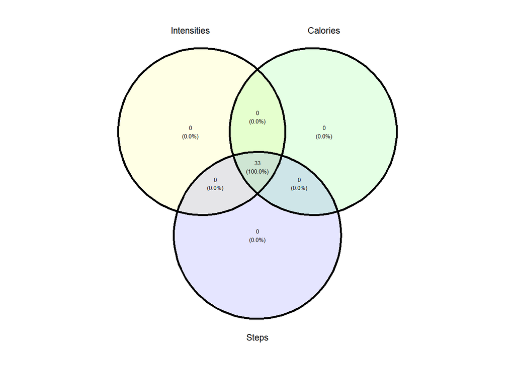

```r
users1 <-list('Intensities'=a5$ID,'Calories'=a6$ID,'Steps'=a7$ID)
# display all the sets
ggvenn(users1,fill_alpha= 0.1,
       fill_color = c("yellow","green", "blue"),
       text_size= 2,
       set_name_size=3)
```

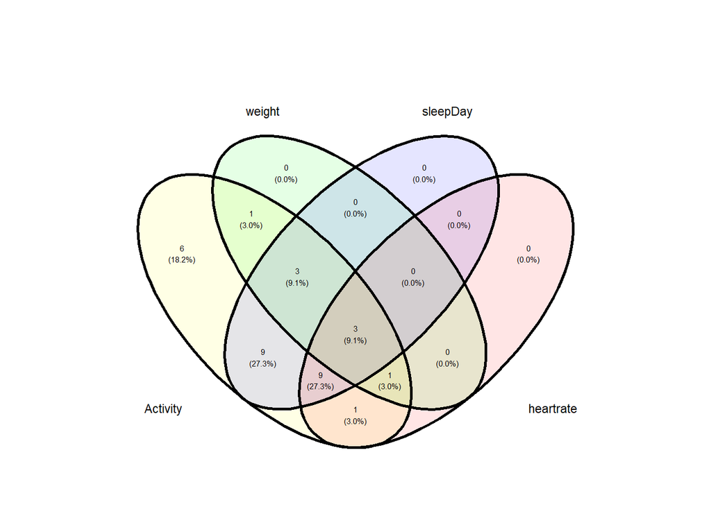

```r
users2 <-list('Activity'=a1$ID,'weight'=a2$ID,'sleepDay'=a3$ID,'heartrate'=a4$ID)
# display all the sets
ggvenn(users2,fill_alpha= 0.1,
       fill_color = c("yellow","green", "blue", "red"),
       text_size= 2,
       set_name_size=3)
```

Let see aour findings:

- We can see that the totality of user in SleepDay(24), are all of them in dailyActivity. First insight: Users that are monitoring their activities, 50%(12/24) of them also are doing it with their heart rate and 25%(6/24) are checking at their weight.
- User that are monitoring their heart rate(14), also all of them are in the main dataset, daily activity. Second insight: Users that are monitoring their heart rate, 86%(12/14) of them also are doing it with their sleep and 28%(4/14) are checking at their weight.
- User that are monitoring their weight(8), also all of them are in the main dataset, daily activity. Third insight: Users that are monitoring their weight, 75%(6/8) of them also are doing it with their sleep and 50%(4/4) are checking at their heart rate.

Anyways there are 18%(6/33) user that are in the dailyActivity, but they are no monitoring heart rate,weight or sleep.

### EDA

```r
# are there NaNs?
colSums(Activity=="")
```

```
##                       Id             ActivityDate               TotalSteps
##                        0                        0                        0
##            TotalDistance          TrackerDistance LoggedActivitiesDistance
##                        0                        0                        0
##       VeryActiveDistance ModeratelyActiveDistance      LightActiveDistance
##                        0                        0                        0
##  SedentaryActiveDistance        VeryActiveMinutes      FairlyActiveMinutes
##                        0                        0                        0
##     LightlyActiveMinutes         SedentaryMinutes                 Calories
##                        0                        0                        0
```

```r
colSums(is.na(Activity))
```

```
##                       Id             ActivityDate               TotalSteps
##                        0                        0                        0
##            TotalDistance          TrackerDistance LoggedActivitiesDistance
##                        0                        0                        0
##       VeryActiveDistance ModeratelyActiveDistance      LightActiveDistance
##                        0                        0                        0
##  SedentaryActiveDistance        VeryActiveMinutes      FairlyActiveMinutes
##                        0                        0                        0
##     LightlyActiveMinutes         SedentaryMinutes                 Calories
##                        0                        0                        0
```

```r
#Checking the unique
apply(Activity,2, function(x) length(unique(x)))
```

```
##                       Id             ActivityDate               TotalSteps
##                       33                       31                      842
##            TotalDistance          TrackerDistance LoggedActivitiesDistance
##                      615                      613                       19
##       VeryActiveDistance ModeratelyActiveDistance      LightActiveDistance
##                      333                      211                      491
##  SedentaryActiveDistance        VeryActiveMinutes      FairlyActiveMinutes
##                        9                      122                       81
##     LightlyActiveMinutes         SedentaryMinutes                 Calories
##                      335                      549                      734
```

```r
#apply(X, MARGIN, FUN)Margin1=row/margin2=Columns
```

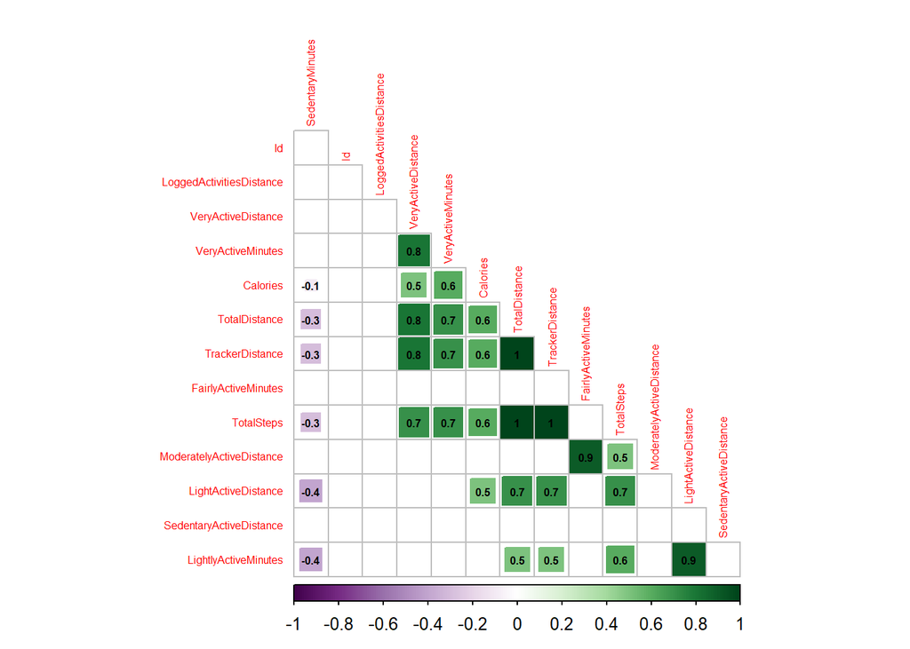

```r
#Calculating Correlation Activity

N1<- round(cor(Activity[, unlist(lapply(Activity, is.numeric))]),1)

testRes = cor.mtest(N1, conf.level = 0.95)
corrplot(N1, p.mat = testRes$p, method = 'square', type = 'lower', insig='blank', tl.cex = 0.5,
         addCoef.col ='black', number.cex = 0.5, order = 'AOE', diag=FALSE,col = COL2('PRGn'))
```

We can see that there is a perfect correlation between Total Distance, Tracker Distance, and Total Steps. Another higher correlation with 0.9 of the coefficient is Fairly Active Minutes and Moderately Active Distance and light Active Distance and Light Active minutes. Although if we analyzed the variable of Very Active Distance has positive relationships with Very Active Minutes, Total Distance, Tracker Distance, and Total Steps. We can see Calories having relationships with a coefficient of 0.6 with Very Active Minutes, and Total Steps 0,7 with Very Active Minutes, Very Active Distance, and Also light Active Distance. Finally, we can see the negative relationship between Sedentary Minutes and some columns having a significative coefficient number of -0,4 with Light Active Minutes and Light Active Distance.

```r
#weekday

dailyActivity$date<- mdy(dailyActivity$Date)


dailyActivity$weekday <- weekdays.POSIXt(dailyActivity$date) # Add a weekday columns
#day
dailyActivity$day<- as.numeric(format(as.Date(dailyActivity$date),"%d"))
#month
dailyActivity$month<- as.numeric(format(as.Date(dailyActivity$date),"%m"))

#day_of_week
#dailyActivity$weekday<- weekdays(as.Date(dailyActivity$date))

#Format day_of_week

head(dailyActivity)
```

```
## # A tibble: 6 × 19
##         Id Date  Total…¹ Total…² Track…³ Logge…⁴ VeryA…⁵ Moder…⁶ Light…⁷ Seden…⁸
##      <dbl> <chr>   <dbl>   <dbl>   <dbl>   <dbl>   <dbl>   <dbl>   <dbl>   <dbl>
## 1   1.50e9 4/12…   13162    8.5     8.5        0    1.88   0.550    6.06       0
## 2   1.50e9 4/13…   10735    6.97    6.97       0    1.57   0.690    4.71       0
## 3   1.50e9 4/14…   10460    6.74    6.74       0    2.44   0.400    3.91       0
## 4   1.50e9 4/15…    9762    6.28    6.28       0    2.14   1.26     2.83       0
## 5   1.50e9 4/16…   12669    8.16    8.16       0    2.71   0.410    5.04       0
## 6   1.50e9 4/17…    9705    6.48    6.48       0    3.19   0.780    2.51       0
## # … with 9 more variables: VeryActiveMinutes <dbl>, FairlyActiveMinutes <dbl>,
## #   LightlyActiveMinutes <dbl>, SedentaryMinutes <dbl>, Calories <dbl>,
## #   date <date>, weekday <chr>, day <dbl>, month <dbl>, and abbreviated
## #   variable names ¹TotalSteps, ²TotalDistance, ³TrackerDistance,
## #   ⁴LoggedActivitiesDistance, ⁵VeryActiveDistance, ⁶ModeratelyActiveDistance,
## #   ⁷LightActiveDistance, ⁸SedentaryActiveDistance
```

```r
summary(dailyActivity)
```

```
##        Id                Date             TotalSteps    TotalDistance
##  Min.   :1.504e+09   Length:940         Min.   :    0   Min.   : 0.000
##  1st Qu.:2.320e+09   Class :character   1st Qu.: 3790   1st Qu.: 2.620
##  Median :4.445e+09   Mode  :character   Median : 7406   Median : 5.245
##  Mean   :4.855e+09                      Mean   : 7638   Mean   : 5.490
##  3rd Qu.:6.962e+09                      3rd Qu.:10727   3rd Qu.: 7.713
##  Max.   :8.878e+09                      Max.   :36019   Max.   :28.030
##  TrackerDistance  LoggedActivitiesDistance VeryActiveDistance
##  Min.   : 0.000   Min.   :0.0000           Min.   : 0.000
##  1st Qu.: 2.620   1st Qu.:0.0000           1st Qu.: 0.000
##  Median : 5.245   Median :0.0000           Median : 0.210
##  Mean   : 5.475   Mean   :0.1082           Mean   : 1.503
##  3rd Qu.: 7.710   3rd Qu.:0.0000           3rd Qu.: 2.053
##  Max.   :28.030   Max.   :4.9421           Max.   :21.920
##  ModeratelyActiveDistance LightActiveDistance SedentaryActiveDistance
##  Min.   :0.0000           Min.   : 0.000      Min.   :0.000000
##  1st Qu.:0.0000           1st Qu.: 1.945      1st Qu.:0.000000
##  Median :0.2400           Median : 3.365      Median :0.000000
##  Mean   :0.5675           Mean   : 3.341      Mean   :0.001606
##  3rd Qu.:0.8000           3rd Qu.: 4.782      3rd Qu.:0.000000
##  Max.   :6.4800           Max.   :10.710      Max.   :0.110000
##  VeryActiveMinutes FairlyActiveMinutes LightlyActiveMinutes SedentaryMinutes
##  Min.   :  0.00    Min.   :  0.00      Min.   :  0.0        Min.   :   0.0
##  1st Qu.:  0.00    1st Qu.:  0.00      1st Qu.:127.0        1st Qu.: 729.8
##  Median :  4.00    Median :  6.00      Median :199.0        Median :1057.5
##  Mean   : 21.16    Mean   : 13.56      Mean   :192.8        Mean   : 991.2
##  3rd Qu.: 32.00    3rd Qu.: 19.00      3rd Qu.:264.0        3rd Qu.:1229.5
##  Max.   :210.00    Max.   :143.00      Max.   :518.0        Max.   :1440.0
##     Calories         date              weekday               day
##  Min.   :   0   Min.   :2016-04-12   Length:940         Min.   : 1.00
##  1st Qu.:1828   1st Qu.:2016-04-19   Class :character   1st Qu.: 9.00
##  Median :2134   Median :2016-04-26   Mode  :character   Median :16.00
##  Mean   :2304   Mean   :2016-04-26                      Mean   :15.79
##  3rd Qu.:2793   3rd Qu.:2016-05-04                      3rd Qu.:23.00
##  Max.   :4900   Max.   :2016-05-12                      Max.   :30.00
##      month
##  Min.   :4.00
##  1st Qu.:4.00
##  Median :4.00
##  Mean   :4.35
##  3rd Qu.:5.00
##  Max.   :5.00
```

We can see that the data start on the 12th of April, 2016, and finish on the 12th of May 2016. The minimum of Calories taken by the users is zero and the maximum is 4.900.

- VeryActiveMinutes have a mean of 21.16 minutes and a maximum of 210 minutes (3.5 hours). _ VeryActiveDistance has a mean of 1.503 kilometers and a maximum of 21.9k.
- FairlyActiveMinutes have a mean of 13.56 minutes and a maximum of 143 minutes(2.38 hours).
- ModeratelyActiveDistance has a mean of 0.5675 kilometers and a maximum of 6.4k.
- LightlyActiveMinutes have a mean of 192 minutes(3.2 hours) and a maximum of 518 minutes(8.63 hours). -LightActiveDistance has a mean of 3.341 kilometers and a maximum of 10.710k

-SedentaryMinutes have a mean of 991.2 minutes(16 hours) and a maximum of 1440.0 minutes(24 hours)

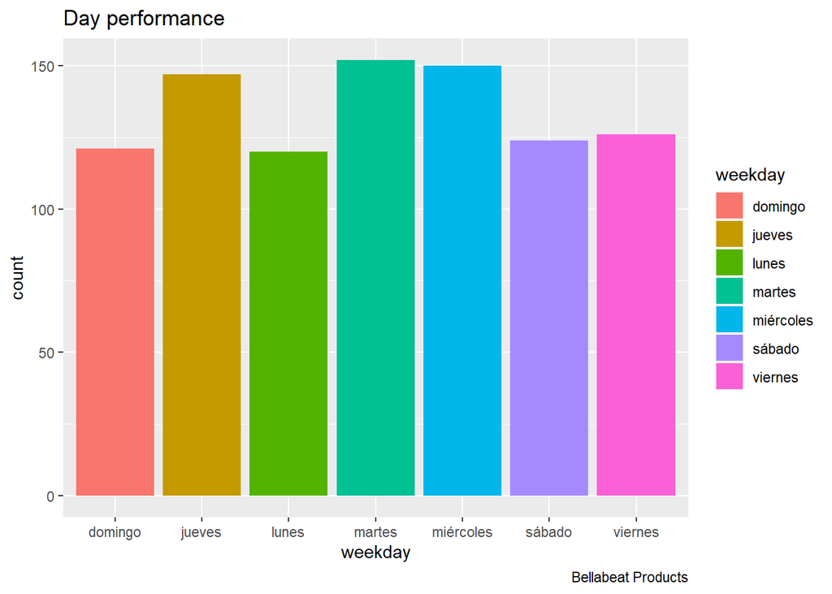

```r
ggplot(data = dailyActivity) + geom_bar(mapping = aes(x =weekday, fill=weekday)) +
  labs(title = "Day performance ",  caption = "Bellabeat Products")
```

We can observate that is Tuesday and then Wednesday when the user are using the products the most and and is Monday which gets the less interaction.

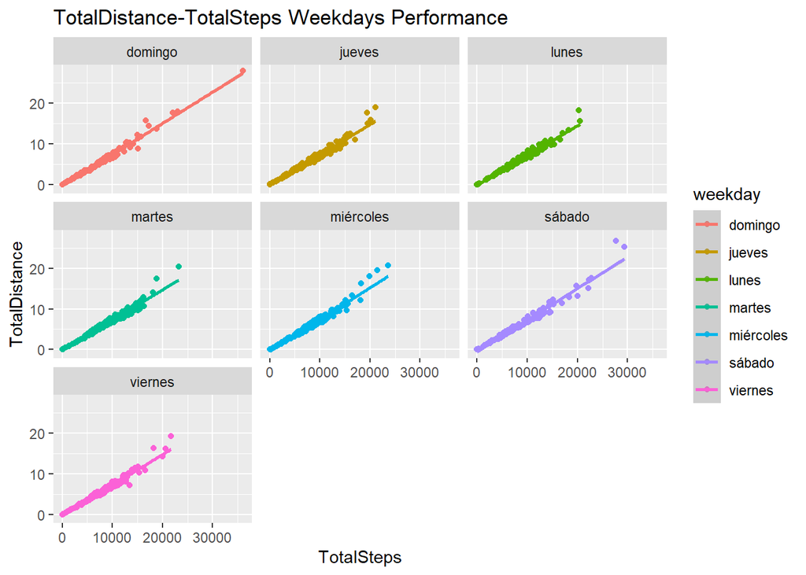

```r
# perfect correlationship TotalSteps and TotalDistance
ggplot(data=dailyActivity, aes(x=TotalSteps, y=TotalDistance, color=weekday)) +geom_point() +stat_smooth(method=lm) +facet_wrap(~weekday) + labs(title = "TotalDistance-TotalSteps Weekdays Performance")
```

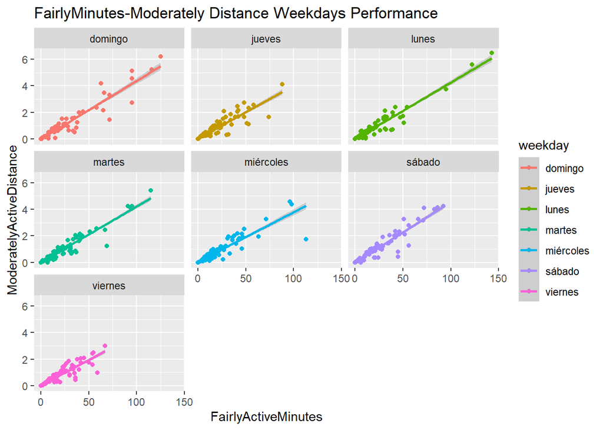

```r
#"FairlyMinutes-Moderately Distance Weekday Performance"
ggplot(data=dailyActivity, aes(x=FairlyActiveMinutes, y=ModeratelyActiveDistance, color=weekday)) +geom_point() +stat_smooth(method=lm) +facet_wrap(~weekday) + labs(title = "FairlyMinutes-Moderately Distance Weekdays Performance")
```

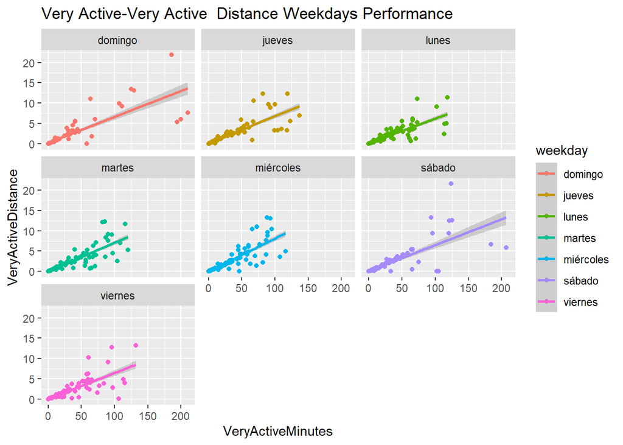

```r
#Very Active -Very Active  Distance Weekday Performance
ggplot(data=dailyActivity, aes(x=VeryActiveMinutes, y=VeryActiveDistance, color=weekday)) +geom_point() +stat_smooth(method=lm) +facet_wrap(~weekday) + labs(title = "Very Active-Very Active  Distance Weekdays Performance")
```

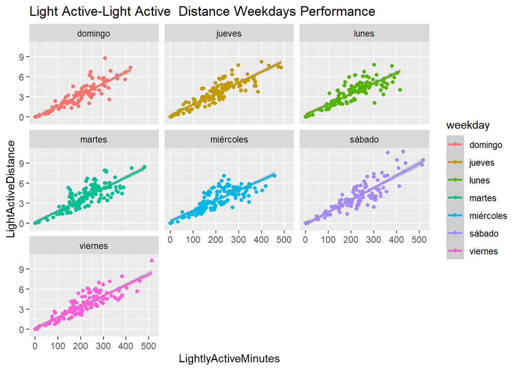

```r
ggplot(data=dailyActivity, aes(x=LightlyActiveMinutes, y=LightActiveDistance, color=weekday)) +geom_point() +stat_smooth(method=lm) +facet_wrap(~weekday) + labs(title = "Light Active-Light Active  Distance Weekdays Performance")
```

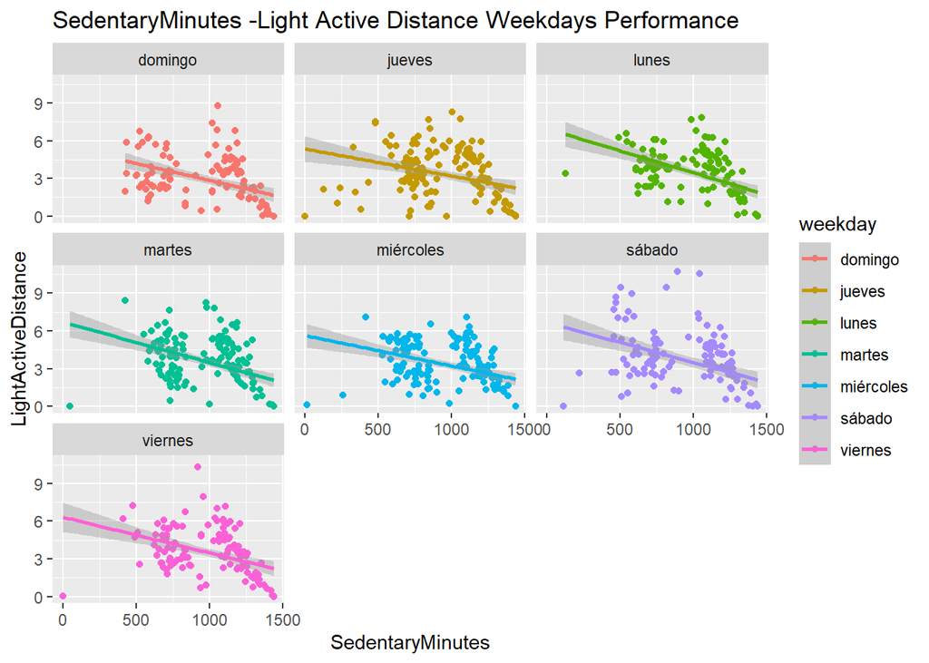

```r
#SedentaryMinutes -Light Active Distance Weekdays Performance
ggplot(data=dailyActivity, aes(x=SedentaryMinutes, y=LightActiveDistance, color=weekday)) +geom_point() +stat_smooth(method=lm) +facet_wrap(~weekday) + labs(title = "SedentaryMinutes -Light Active Distance Weekdays Performance")
```

Total Distance-Total Steps Weekday Performance, we can see that weekends has better accomplishment here, - Fairly Minutes-Moderately Distance Weekday Performance, it is Monday which has the highest yield, followed by Sunday, it goes in between 4K and 100 minutes daily, being the worst Friday - Very Active -Very Active Distance Weekday Performance, just as the first plot Weekends people are doing 200 minutes and almost reaching 15K -Light Active-Light Active Distance Weekday Performance, It has a more smooth performance that is around 7k daily with also regular 400–500 minutes daily. -Sedentary Minutes -Light Active Distance Weekdays Performance we can see that here we have a negative correlation because when more Sedentary Minutes less Light Active Distance reaching 3k daily. Let’s see another relationship.

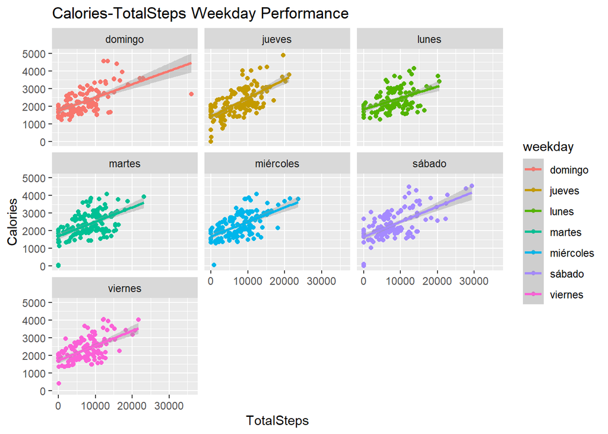

```r
ggplot(data=dailyActivity, aes(x=TotalSteps, y=Calories, color=weekday)) +geom_point() +stat_smooth(method=lm) +facet_wrap(~weekday) + labs(title = "Calories-TotalSteps Weekday Performance")
```

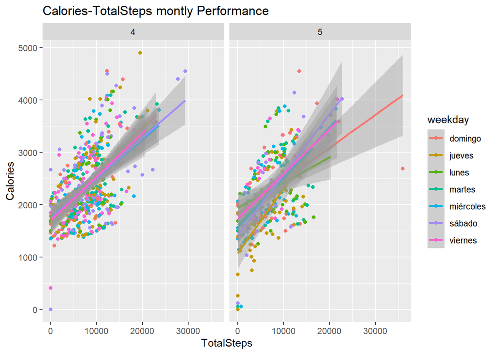

```r
ggplot(data=dailyActivity, aes(x=TotalSteps, y=Calories, color=weekday)) +geom_point() +stat_smooth(method=lm) +facet_wrap(~month)+ labs(title = "Calories-TotalSteps montly Performance")
```

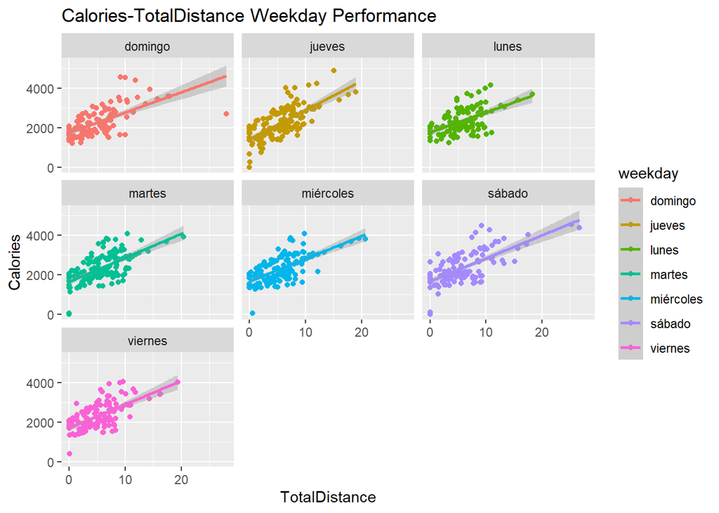

```r
ggplot(data=dailyActivity, aes(x=TotalDistance, y=Calories, color=weekday)) +geom_point() +stat_smooth(method=lm) +facet_wrap(~weekday) + labs(title = "Calories-TotalDistance Weekday Performance")
```

[figure not shown]

```r
ggplot(data=dailyActivity, aes(x=TotalDistance, y=Calories, color=weekday)) +geom_point() +stat_smooth(method=lm) +facet_wrap(~month) + labs(title = "Calories-TotalSteps montly Performance")
```

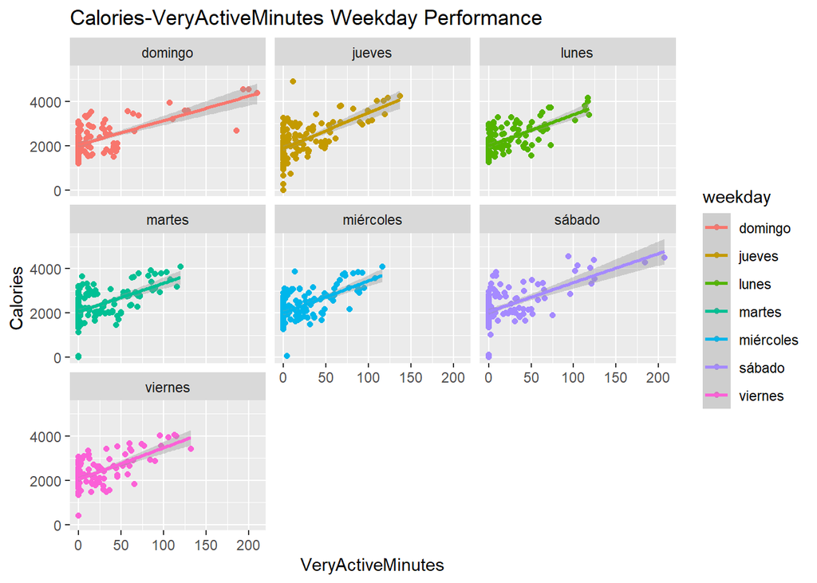

```r
ggplot(data=dailyActivity, aes(x=VeryActiveMinutes, y=Calories, color=weekday)) +geom_point() +stat_smooth(method=lm) +facet_wrap(~weekday) + labs(title = "Calories-VeryActiveMinutes Weekday Performance")
```

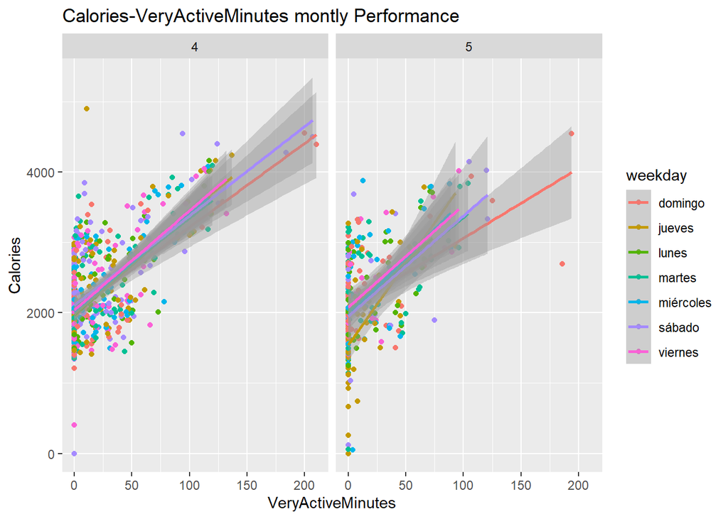

```r
ggplot(data=dailyActivity, aes(x=VeryActiveMinutes, y=Calories, color=weekday)) +geom_point() +stat_smooth(method=lm) +facet_wrap(~month) + labs(title = "Calories-VeryActiveMinutes montly Performance")
```

## Refences

- Reference: Calbimonte D. (2021-10-21).”Ways to compare and find differences for SQL Server tables and data”. Recovered el 23 December of 2022 https://www.mssqltips.com/sqlservertip/2779/ways-to-compare-and-find-differences-for-sql-server-tables-and-data